# wheels_notebook

```python
 #Scientific libraries
import numpy as np
import pandas as pd

#Visualization
import matplotlib.pyplot as plt
import seaborn as sns
%matplotlib inline
```

```python
#Configurations
import warnings
warnings.filterwarnings("ignore")

pd.set_option('display.max_colwidth', 600)
```

```python
#Loading data

df = pd.read_csv(r'C:\Users\reloef\Downloads\new_wheels_proj\cust_state.csv')
df = pd.DataFrame(df, index = None)
df = df.head(5)
df.head()
```

|  | state | NUMBER_OF_CUSTOMERS |
| --- | --- | --- |
| 0 | California | 97 |
| 1 | Texas | 97 |
| 2 | Florida | 86 |
| 3 | New York | 69 |
| 4 | District of Columbia | 35 |

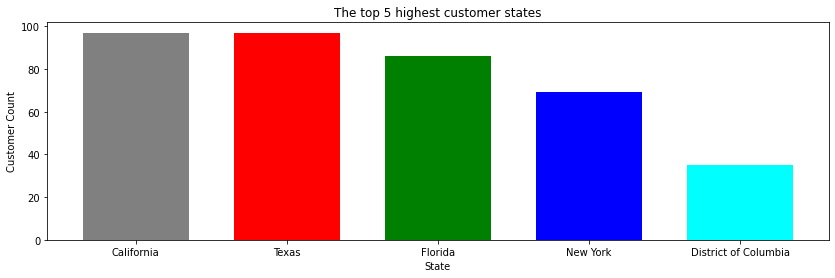

```python
# Creating a bar chart with the parameters
plt.figure(figsize=(14, 4))
plt.bar(df['state'], df['NUMBER_OF_CUSTOMERS'], width=0.7, align='center', color=['grey','red', 'green', 'blue', 'cyan'])
plt.title('The top 5 highest customer states')
plt.xlabel('State', fontsize=10)
plt.ylabel('Customer Count', fontsize=10)
plt.show()
```

OBSERVATION:

1. Califonia and TEXAS has the same number of customers.
2. District of Columbia state has the lowest customers of the top 5 highest customers state

```python
#Loading data

df = pd.read_csv(r'C:\Users\reloef\Downloads\new_wheels_proj\average_quarter_rating.csv')
df1 = df.copy()
df1.head()
```

|  | quarter_number | avg_rating |
| --- | --- | --- |
| 0 | 4 | 2.3970 |
| 1 | 1 | 3.5548 |
| 2 | 3 | 2.9563 |
| 3 | 2 | 3.3550 |

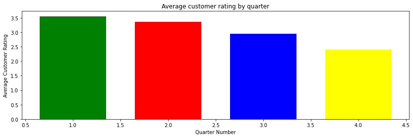

```python
# Creating a bar chart with the parameters
plt.figure(figsize=(14, 4))
plt.bar(df1['quarter_number'], df1['avg_rating'], width=0.7, align='center', color=['yellow', 'green', 'blue', 'red'])
plt.title('Average customer rating by quarter')
plt.xlabel('Quarter Number', fontsize=10)
plt.ylabel('Average Customer Rating', fontsize=10)
plt.show()
```

OBSERVATION

1. The first quarter has the highest average customer rating
2. The fourth quarter has the lowest average cuatomer rating
3. The average customer ratings are showing over time

```python
#Loading data

df = pd.read_csv(r'C:\Users\reloef\Downloads\new_wheels_proj\popular_car_maker.csv')
df2 = df.copy()
df2 = df2.head(20)
```

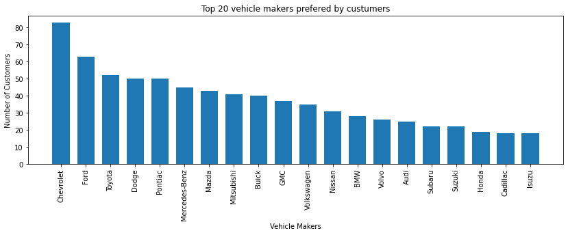

```python
# Creating a bar chart with the parameters
plt.figure(figsize=(14, 4))
plt.bar(df2['vehicle_maker'], df2['count(vehicle_maker)'], width=0.7, align='center')
plt.title('Top 20 vehicle makers prefered by custumers')
plt.xlabel('Vehicle Makers', fontsize=10)
plt.xticks(rotation=90)
plt.ylabel('Number of Customers', fontsize=10, Rotation = 'vertical')
plt.show()
```

OBSERVATIONS

1. N is defined 20 thus the bar plot present top 20 car makers prefered by customes
2. Chevrolet and Ford are the leading top brand prefered by customers [Shows American pride i.e. most American prefer local cars]
3. Car makers with low interest are brands known to be expensinse and with less variaty of car models
4. Toyota is the third highest prefered and this could be attributed to the fact that the Car Maker has many options for vehicles.

```python
#Loading data

df = pd.read_csv(r'C:\Users\reloef\Downloads\new_wheels_proj\pop_car_per_state.csv')
df2 = df.copy()
df2.head()
```

|  | vehicle_maker | state | cust_counts |
| --- | --- | --- | --- |
| 0 | Mazda | Ohio | 33 |
| 1 | GMC | Florida | 86 |
| 2 | Plymouth | New York | 69 |
| 3 | Ford | Maryland | 15 |
| 4 | Isuzu | Missouri | 23 |

```python
from tabulate import tabulate

table = [[df2['state']],[df2['vehicle_maker']]]
print(tabulate(table, headers = ['State','Vehicle Maker'] , tablefmt='fancy_grid'))
pd.set_option('display.max_rows', None)
pd.set_option('display.max_columns', None)
pd.set_option('display.width', None)
pd.set_option('display.max_colwidth', None)
```

[output not shown]

[output cut: 50 more lines]

[output not shown]

```python
#Loading data

df = pd.read_csv(r'C:\Users\reloef\Downloads\new_wheels_proj\ord_q.csv')
df2 = df.copy()
df2.sort_values(by=['quarter_number'])
df2.head()
```

|  | quarter_number | q_total_orders |
| --- | --- | --- |
| 0 | 1 | 310 |
| 1 | 2 | 262 |
| 2 | 3 | 229 |
| 3 | 4 | 199 |

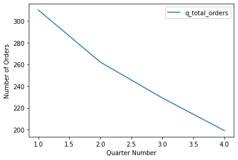

```python
plt.figure(figsize=(20, 4))
df2.plot(x="quarter_number", y=['q_total_orders'])
plt.xlabel('Quarter Number', fontsize=10)
plt.ylabel('Number of Orders', fontsize=10)
```

OBSERVATIONS

1. All orders are above 190 for all quarters.
2. The first quarter had the highest order and the fourth quarter had the lowest orders
3. The graphs shows a decrease linear trend
4. The order reduced by approximately 100 orders for whole duration
5. From quarter 1 to quarter 2 the decrease slope is much steeper than on the rest of the quarters [initial sharp decline in orders]

```python
#Loading data

df = pd.read_csv(r'C:\Users\reloef\Downloads\new_wheels_proj\%rev_difference.csv')
df2 = df.copy()
df2.sort_values(by=['quarter_number'])
df2.head()
```

|  | quarter_number | revenue | revenue_prev_q | rev_difference |
| --- | --- | --- | --- | --- |
| 0 | 1 | 2.160508e+07 | NaN | NaN |
| 1 | 2 | 1.979074e+07 | 2.160508e+07 | -9.167615 |
| 2 | 3 | 2.055313e+07 | 1.979074e+07 | 3.709346 |
| 3 | 4 | 1.492286e+07 | 2.055313e+07 | -37.729162 |

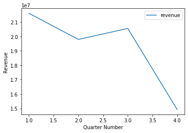

```python
plt.figure(figsize=(20, 4))
df2.plot(x="quarter_number", y=['revenue'])
plt.xlabel('Quarter Number', fontsize=10)
plt.ylabel('Revenue', fontsize=10)
```

OBSERVATION

1. FROM quarter 1 to quarter 2 the revenue decrease by approximately 9.2%
2. FROM quarter 2 to quarter 3 the revenue increased by approximately 3.7%
3. FROM quarter 3 to quarter 4 the revenue decreased sharpy by approximately 37.7%
4. The sharp decrease on the last quarter difference can be attributed to low orders and most concerning bad rating from customers

```python
#Loading data

df = pd.read_csv(r'C:\Users\reloef\Downloads\new_wheels_proj\orders_vs_rev.csv')
df2 = df.copy()

df2.head()
```

|  | quarter_number | revenue | total_orders |
| --- | --- | --- | --- |
| 0 | 1 | 21605081.07 | 310 |
| 1 | 2 | 19790742.00 | 262 |
| 2 | 3 | 20553128.64 | 229 |
| 3 | 4 | 14922858.94 | 199 |

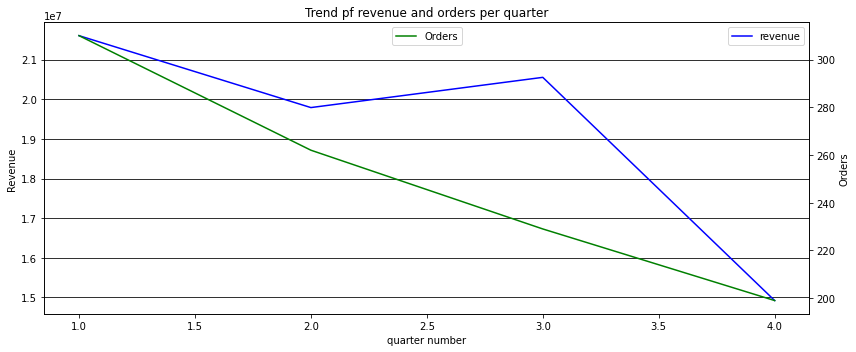

```python
fig, ax = plt.subplots(figsize=(12,5))
ax2 = ax.twinx()
ax.set_title('Trend pf revenue and orders per quarter')
ax.set_xlabel('quarter number')
ax.plot(df2['quarter_number'], df2['revenue'], color='blue')
ax2.plot(df2['quarter_number'], df2['total_orders'], color='green')
ax.set_ylabel('Revenue')
ax2.set_ylabel('Orders')
ax.legend(['revenue'], loc='upper right')
ax2.legend(['Orders'], loc='upper center')

ax.yaxis.grid(color='black')
plt.tight_layout()
plt.show()
```

OBSERVATION

1. The revenue and orders graphs follow the same linearly decreasing trend even thought revenue shows positve linear trend on quarter 2 and 3.
2. The higher the orders the higer the revenue and the latter is holds with an exception of between quarter 2 and 3.

```python
    #Loading data

    df = pd.read_csv(r'C:\Users\reloef\Downloads\new_wheels_proj\avg_discount_cardtype.csv')
    df2 = df.copy()

    df2.head()
```

|  | credit_card_type | avg_discount |
| --- | --- | --- |
| 0 | laser | 0.643846 |
| 1 | mastercard | 0.629500 |
| 2 | maestro | 0.624219 |
| 3 | visa-electron | 0.623469 |
| 4 | china-unionpay | 0.622174 |

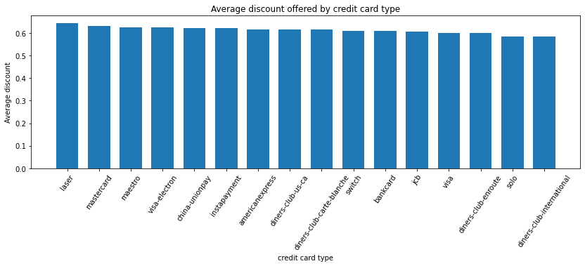

```python
# Creating a bar chart with the parameters
plt.figure(figsize=(14, 4))
plt.bar(df2['credit_card_type'], df2['avg_discount'], width=0.7, align='center')
plt.title('Average discount offered by credit card type')
plt.xlabel('credit card type', fontsize=10)
plt.xticks(rotation=55)
plt.ylabel('Average discount', fontsize=10, Rotation = 'vertical')
plt.show()
```

```python
#Loading data

df = pd.read_csv(r'C:\Users\reloef\Downloads\new_wheels_proj\avg_time_q.csv')
df2 = df.copy()

df2.head()
```

|  | quarter_number | avg_duration |
| --- | --- | --- |
| 0 | 4 | 174.0955 |
| 1 | 3 | 117.7555 |
| 2 | 2 | 71.1107 |
| 3 | 1 | 57.1677 |

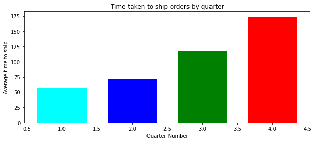

```python
# Creating a bar chart with the parameters
plt.figure(figsize=(10, 4))
plt.bar(df2['quarter_number'], df2['avg_duration'], width=0.7, align='center', color=['red', 'green', 'blue', 'cyan'])
plt.title('Time taken to ship orders by quarter')
plt.xlabel('Quarter Number', fontsize=10)
plt.ylabel('Average time to ship', fontsize=10)
plt.show()
```

OBSERVATION

1. First querter delivery service was quick even though orders were many
2. On the fourth quarter the delivery time is almost tripple times slower than first quarter.
3. Delivery time shows to be taking longer as quarters increase.

```python
#Loading data

df = pd.read_csv(r'C:\Users\reloef\Downloads\new_wheels_proj\%quarter_rating_.csv')
df2 = df.copy()

df2.head()
```

|  | quarter_number | total_counts | very_good | very_bad | okay | good | bad |
| --- | --- | --- | --- | --- | --- | --- | --- |
| 0 | 4 | 199 | 10.0503 | 30.6533 | 20.1005 | 10.0503 | 29.1457 |
| 1 | 1 | 310 | 30.0000 | 10.9677 | 19.0323 | 28.7097 | 11.2903 |
| 2 | 3 | 229 | 16.5939 | 17.9039 | 21.8341 | 20.9607 | 22.7074 |
| 3 | 2 | 262 | 28.6260 | 14.8855 | 20.2290 | 22.1374 | 14.1221 |

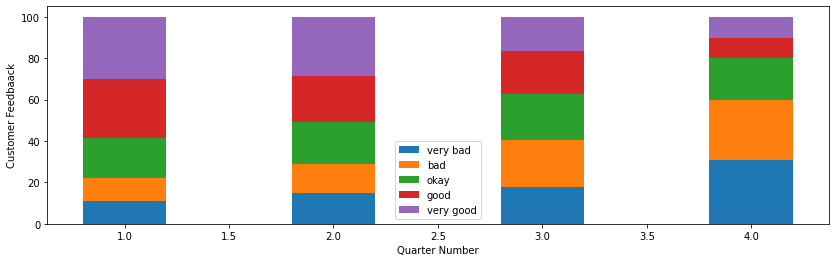

```python
#label = [good, very good, bad, very bad, okay]
x = df['quarter_number']
ygood = df['good']
yvgood = df['very_good']
yokay = df['okay']
ybad = df['bad']
yvbad = df['very_bad']

#btm = list(np.add(ybad,yokay,ygood))
plt.figure(figsize=(14, 4))
plt.bar(x,yvbad,0.4, label = 'very bad')
plt.bar(x,ybad,0.4, bottom = yvbad,label = 'bad')
plt.bar(x,yokay,0.4, bottom = ybad+yvbad, label = 'okay')
plt.bar(x,ygood,0.4, bottom = yokay+ybad+yvbad, label = 'good')
plt.bar(x,yvgood,0.4, bottom = ygood+yokay+ybad+yvbad, label = 'very good')

plt.xlabel('Quarter Number')
plt.ylabel('Customer Feedbaack')
plt.legend()
plt.show()
```

OBSERVATIONS

1. Very good and good sentiments is decreasing as quarter number increase
2. Okay sentiment is not showing much change as quarter increase
3. bad and very bad sentiment increasing as quarter number increase
4. This shows an overall decline in custmore satisficaton.